# TP5 Análisis Exploratorio de Datos

Barrera Borla, Berros & Duarte

16 de julio de 2018 EC

Cargamos librerías y código auxiliar:

```r
library(tidyverse)
library(glue)

set.seed(42)

source("R/leer_dataset.R")
source("R/pca.R")
source("R/k_medias.R")
source("R/helpers.R")
source("R/dbscan.R")
source("R/funcion_dibujar_planeta.R")
source("vignettes/acumulacion_espacial.R")
```

# 1.1 PCA y K-medias

Leemos y escalamos el dataset. La razón para centrar cada columna en cero es que el PCA se computa más fácilmente de ese modo. La razón para estandarizar cada columna (dividiendo por el desvío) es para compensar la diferencia de unidades entre las variables del dataset. Sin la estandarización, las variables con mayor valor absoluto de varianza cooptarían los primeros componentes principales de un PCA, por un lado, y dominarían también el cálculo de distancias euclídeas al centroide en el algoritmo K-medias.

```r
wine <- leer_dataset("data/wine.txt")
wine_escalado <- scale(wine) %>% as_tibble
```

Agrupamos los datos utilizando el algoritmo **K-medias**. Tras algunas pruebas a mano, decidimos que el dataset puede dividirse en 3 grupos, pero de todos modos computamos la clusterización para varios valores de k:

```r
resultados_k_means <-
  tibble(k = 2:6) %>%
  mutate(categorias = map(k, ~k_medias(wine_escalado, k = .x, verboso = T))) %>%
  mutate(categorias = map(categorias, ~.x$cluster_id))

categorias_por_k <- resultados_k_means$categorias
names(categorias_por_k) <- resultados_k_means$k
```

Queremos ver cuán bien fueron agrupados los datos con K-medias, pero el dataset tiene 13 dimensiones, lo que dificulta su visualización. Vamos a realizar entonces un **análisis de componentes principales (PCA)** para obtener unos pocos ejes (componentes principales o PCs), sobre los cuales proyectar los datos y poder así visualizar el agrupamiento.

```r
pca <- analisis_de_componentes_principales(wine_escalado)
```

Observemos el porcentaje de varianza explicado al considerar progresivamente más componentes principales:

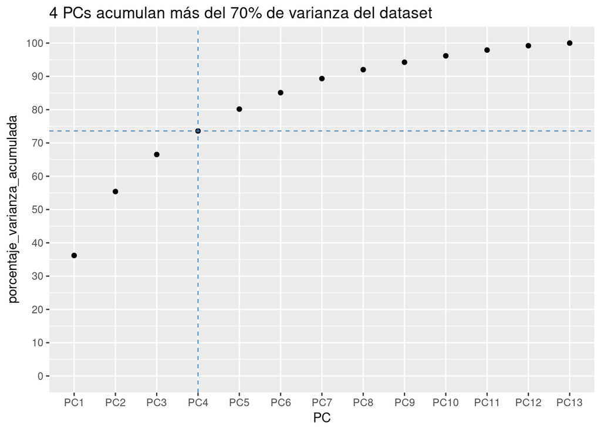

```r
porcentaje_varianza <- tibble(
  PC = names(pca$varianza_explicada),
  porcentaje_varianza = pca$varianza_explicada * 100,
  porcentaje_varianza_acumulada = cumsum(porcentaje_varianza)
)

porcentaje_varianza %>%
  ggplot() +
    aes(x = PC, y = porcentaje_varianza_acumulada) +
    geom_point() +
    ggtitle("4 PCs acumulan más del 70% de varianza del dataset") +
    geom_hline(yintercept = 73.6, color = "SteelBlue",
               linetype = "dashed", size = 0.4) +
    geom_vline(xintercept = 4, color = "SteelBlue",
               linetype = "dashed", size = 0.4) +
    scale_x_discrete(limits = porcentaje_varianza$PC) +
    scale_y_continuous(breaks = seq(0, 100, by = 10), limits = c(0, 100))
```

Puede apreciarse que con 4 componentes principales resumimos más del 70% de la varianza total del dataset. Sin embargo, la estructura más interesante se observa con los PC1 y PC2, de modo que nos limitaremos a graficar esos componentes.

Por otro lado, graficamos las “cargas” (*loadings*) de los dos primeros componentes principales para las 13 variables del dataset, de modo de identificar si algunas variables particulares se llevan la mayor parte de la varianza:

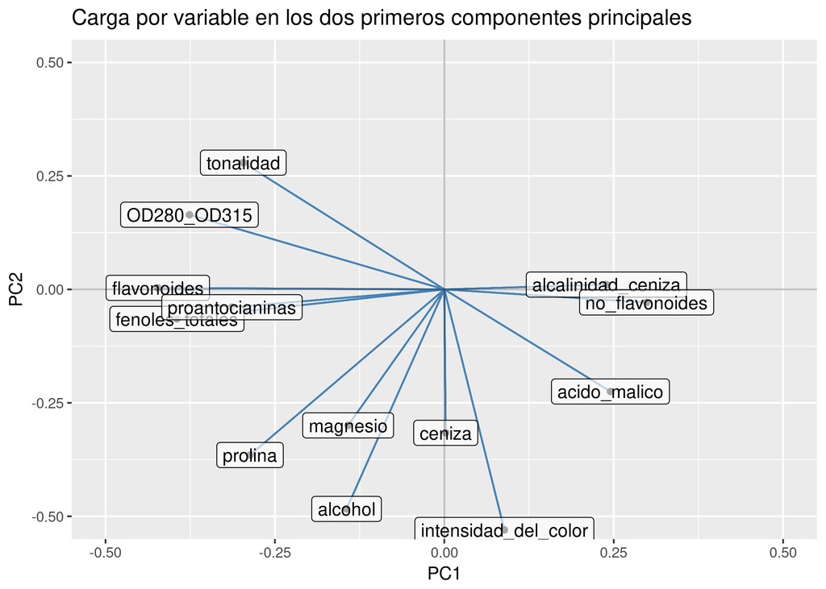

```r
vectores_de_carga <-
  pca$matriz_de_autovectores %>%
  as_tibble %>%
  mutate(predictor = names(wine)) %>%
  rename(PC1 = V1, PC2 = V2)

fig_loadings <-
  vectores_de_carga %>%
  ggplot(aes(PC1, PC2))

for (i in 1:nrow(vectores_de_carga)) {
  xend <- vectores_de_carga[[i, "PC1"]]
  yend <- vectores_de_carga[[i, "PC2"]]
  fig_loadings <-
    fig_loadings +
    geom_segment(x = 0, y = 0, xend = xend, yend = yend,
                 alpha = 0.35, color = "SteelBlue")
}

fig_loadings <-
  fig_loadings +
  geom_point() +
  ggtitle("Carga por variable en los dos primeros componentes principales") +
  geom_label(mapping = aes(label = predictor), alpha = 0.65) +
  geom_hline(yintercept = 0, alpha = 0.25) +
  geom_vline(xintercept = 0, alpha = 0.25) +
  coord_cartesian(xlim = c(-0.5, 0.5), ylim = c(-0.5, 0.5))

ggsave(fig_loadings, filename = "imgs/cargas_PC1_PC2.png")
```

El primer componente principal reúne principalmente la variación de fenoles en el vino, ya sea fenoles flavonoides o no flavonoides, además de otras características como la tonalidad y el contenido de prolina y de ácido málico. Algunas correlaciones deberían ser analizadas por un experto del vino: el contenido de proantocianinas parece altamente correlacionado con el de fenoles flavonoides y la proporción OD<sub>280</sub>/OD<sub>315</sub>, mientras que el de los fenoles no flavonoides con la alcalinidad de la ceniza.

El segundo componente principal, por otro lado, resume aproximadamente otro conjunto de características: el contenido de magnesio, prolina, alcohol, la intensidad del color y la tonalidad. Algunas de estas variables se reparten entre PC1 y PC2, de modo que la interpretación química-vinícola de los PCs no es tan transparente y debe realizarse con precaución.

Grafiquemos ahora el agrupamiento de K-medias proyectado sobre los primeros dos primeros componentes principales.

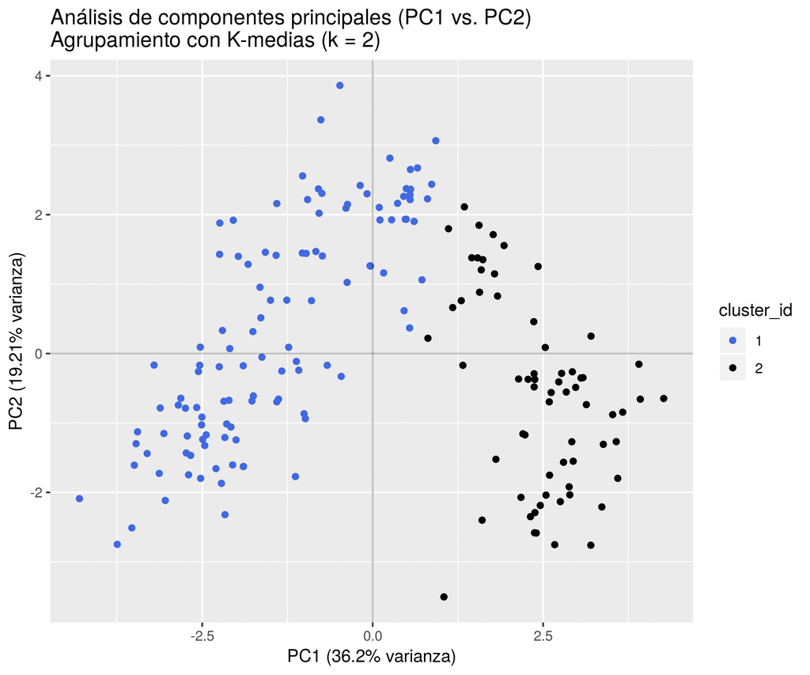

```r
graficar_pca <- function(pc_x, pc_y, k) {
  pca_con_clusters <-
    pca$Z %>%
    mutate(cluster_id = categorias_por_k[[glue("{k}")]])

  pcx_var <- ratio_a_porcentaje(pca$varianza_explicada[[pc_x]])
  pcy_var <- ratio_a_porcentaje(pca$varianza_explicada[[pc_y]])

  n <- nrow(pca_con_clusters)
  colorines <- c("RoyalBlue", "Black", "Tomato", "ForestGreen",
                 "Chocolate", "HotPink", "GoldenRod")

  title <- paste("Análisis de componentes principales ({pc_x} vs. {pc_y})",
                 "Agrupamiento con K-medias (k = {k})", sep="\n")

  fig <- pca_con_clusters %>%
    ggplot() +
    aes_string(x = pc_x, y = pc_y, color = "cluster_id") +
    geom_point() +
    geom_hline(yintercept = 0, alpha = 0.25) +
    geom_vline(xintercept = 0, alpha = 0.25) +
    ggtitle(glue(title)) +
    xlab(glue("{pc_x} ({pcx_var}% varianza)")) +
    ylab(glue("{pc_y} ({pcy_var}% varianza)")) +
    scale_color_manual(values = colorines)

  ggsave(fig, filename = glue("imgs/{pc_x}_{pc_y}_k{k}.png"),
         width = 18, height = 15, units = "cm")
  return (fig)
}

for (k in names(categorias_por_k)) {
  fig <- graficar_pca("PC1", "PC2", k)
}

# Comando para generar el GIF en Linux, con ImageMagick:
# $ convert -delay 200 -loop 0 imgs/PC1_PC2*png imgs/PC1_PC2.gif
```

El agrupamiento que juzgamos más interesante en la proyección al espacio de los dos primeros componentes principales es el generado con $k = 3$, donde se distinguen dos grupos bien diferenciados en los cuadrantes “sudoeste” y “sudeste” y un gran grupo en el “hemisferio norte” del gráfico. Este dataset completo conforma un continuo y, al no haber cortes bruscos en la distribución de datos en este subespacio de dos dimensiones, la preferencia de $k = 3$ es necesariamente arbitraria.

(**Nota**: esta distribución de “tipos” en forma de U, cuyos extremos están bien diferenciados, pero unidos en el centro por un continuo de variación sin cortes bruscos, recuerda al concepto de *ring species* en biología evolutiva y las dificultades que conlleva a la hora de subclasificar.)

# Ejercicio 2 (DBSCAN)

## Generación del Planeta

Para obtener los conjuntos pedidos, dado que es conveniente ir experimentando con diversas cantidades de puntos, es conveniente definir una función que nos da el planeta y su anillo tomando como parámetro la cantidad de puntos que el cuerpo de este debe contener. Esta función es `R/funcion_dibujar_planeta.R`.

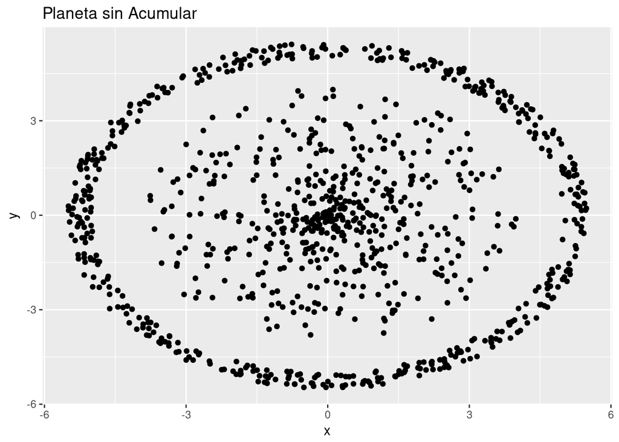

```r
planeta_chico <- dibujar_planeta(200)
planeta_y_anillo <- dibujar_planeta(500)

planeta_y_anillo %>% ggplot() +
  aes(x=x,y=y) +
  geom_point() +
  ggtitle("Planeta sin Acumular")
```

## Clasificación de la Órbita y el Planeta

Realizamos dos implementaciones del algoritmo que constan en la carpeta `R`. La primera se llama `R/dbscan.R` y corresponde a lo visto en clase. Además, hicimos un intento con un algoritmo que realizase el cálculo de las distancias la menor cantidad de veces posibles y minimizase los recorridos sobre la tabla, este (`R/acumulacion_espacial.R`) resultó ser apreciablemente más lento y complejo pero parece tolerar mejor las condiciones adversas. Es de notar que el problema fue específicamente diseñado para que este algoritmo lo resuelva con facilidad y por lo tanto no pusimos realmente bajo demanda ninguna de las dos implementaciones (a pesa de eso, hacemos un intento al final con el planeta de pocos puntos). Uno de los atributos más interesantes de este algoritmo es la posibilidad de determinar que los puntos problemáticos son “ruido”, peron en el caso del planeta con 1000 puntos esto no es necesario y al final de la evaluación no hay puntos clasificados como ruido.

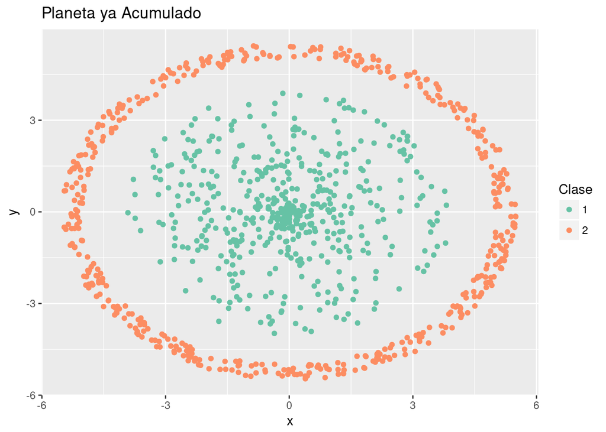

```r
planeta_clasificado <- planeta_y_anillo %>%
  mutate(clase = dbscan(planeta_y_anillo[c("x", "y")], min_pts = 4, epsilon = .8))

planeta_clasificado %>% ggplot( ) +
  aes(x=x,y=y) +
  geom_point( aes(color=as.factor(clase)) ) +
  scale_color_brewer(palette = "Set2", name="Clase") +
  ggtitle("Planeta ya Acumulado")
```

### Animación de las Etapas del Proceso

Para ver mejor cómo funciona el algoritmo y aprovechando que este sigue una hermenéutica de corte netamente gráfico, realizamos una animación de su progreso. El método empleado fue guardar el estado del conjunto de datos en cada recursión del algoritmo y realizar un gráfico de cada uno de esos estados, cosa que cosnta en `R/armar_gif.R` para la obtención de las matrices y en `R/armar_gif.R` para la obtención de los gráficos. Después usamos el comando `convert` de la suite *imagemagick*.

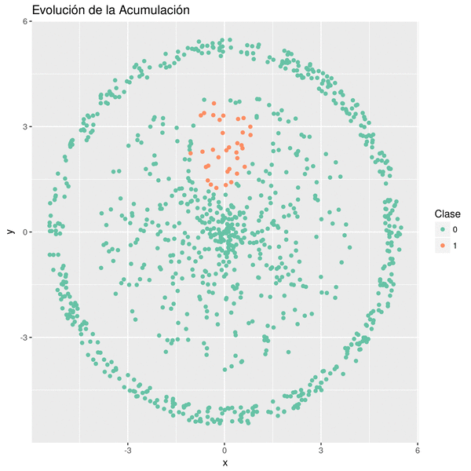

### Efectos de las Condiciones Adversas Sobre el Resultado

Es interesante ver que el algoritmo *converge* a una menor cantidad de clases en tanto el parámetro *radio de los entornos de evaluación* que llamamos `epsilon` se ajusta correctamente a la densidad típica de los puntos. Ante la situación de reducción de este valor los algoritmos mostraron una sensibilidad diferente. Evidentemnte, el planeta con cantidad reducida de puntos introduce antes los inconvenientes.

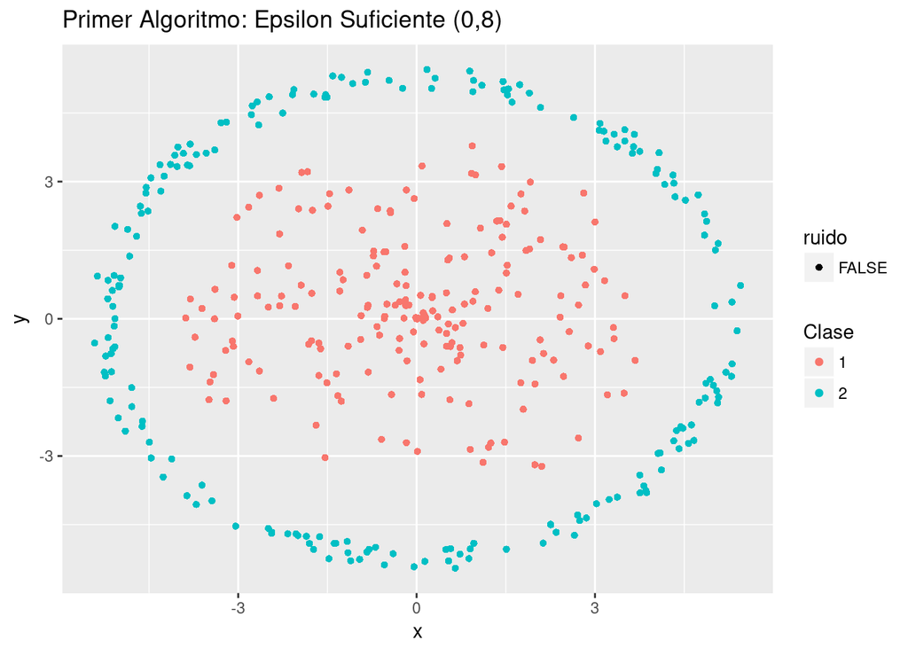

```r
algo1_1 <- preparar_para_acumular( planeta_chico )
algo1_1 <- acumulacion(algo1_1,0.8,4)

algo1_2 <- preparar_para_acumular( planeta_chico )
algo1_2 <- acumulacion(algo1_2,0.4,4)

algo2_1 <- planeta_chico %>%
  mutate(clase = dbscan(planeta_chico[c("x", "y")], min_pts = 4, epsilon = 0.8)) %>%
  mutate(ruido = ifelse(clase==-1,T,F))

algo2_2 <- planeta_chico %>%
  mutate(clase = dbscan(planeta_chico[c("x", "y")], min_pts = 4, epsilon = 0.4)) %>%
  mutate(ruido = ifelse(clase==-1,T,F))

graficar_con_ruido(algo1_1,"Primer Algoritmo: Epsilon Suficiente (0,8)")
```

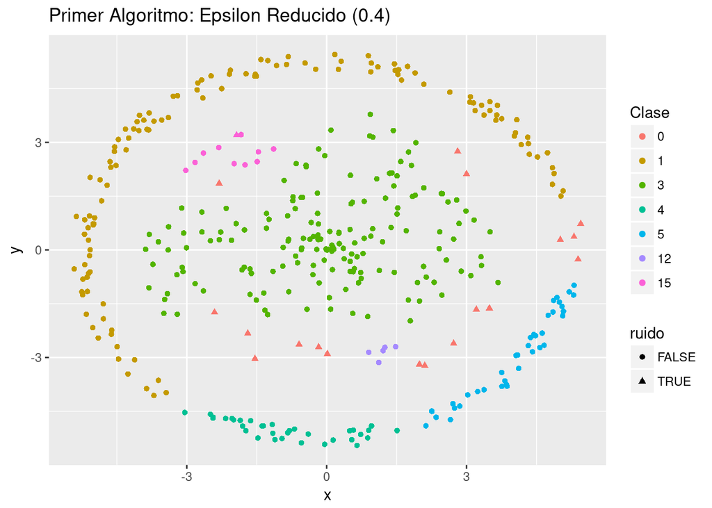

```r
graficar_con_ruido(algo1_2,"Primer Algoritmo: Epsilon Reducido (0.4)")
```

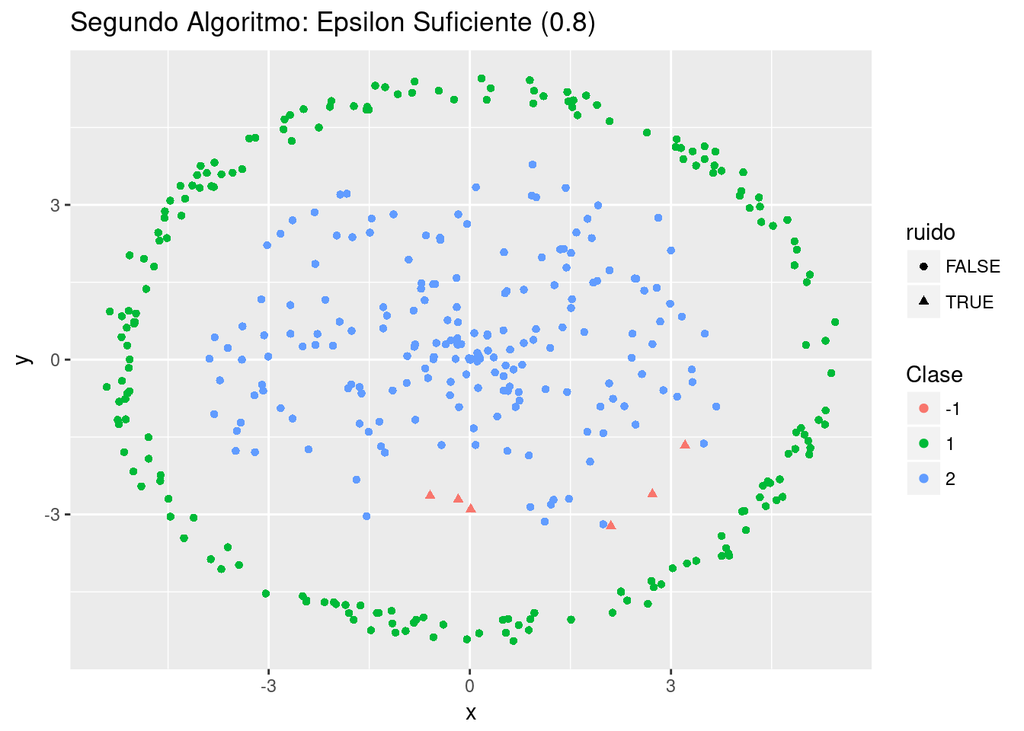

```r
graficar_con_ruido(algo2_1,"Segundo Algoritmo: Epsilon Suficiente (0.8)")
```

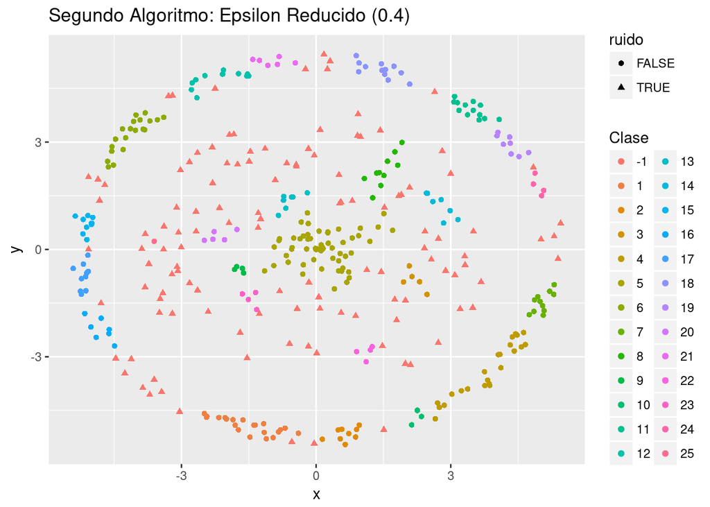

```r
graficar_con_ruido(algo2_2,"Segundo Algoritmo: Epsilon Reducido (0.4)")
```

Un efecto interesante observado es cómo en el *Algoritmo 2 con epsilon suficiente* el algoritmo logra no crear una clase que no se condice con la solución que queremos recurriendo a clasficar puntos como ruido, mostrando que este es el recurso para los conjuntos patológicamente complejos donde no alcanza con determinar el radio de vecindad para lograr la separación deseada.